# LLM Refusal Strategy — RX Working Draft

Polite Refusals team

2026-05-25

# 3. Layer 1: Refusal basis among Non-compliance

This working draft focuses on **in-voice refusals**: cases where the model returned text and the judge coded the response as Non-compliance. Service-level refusals are counted in the overall refusal-rate discussion, but they are not included in L1/L2 form comparisons because there is no model voice to classify.

## 3.2 In-voice view (judged refusals only)

```r
l1_headline <- df_nc |>
  count(layer1) |>
  mutate(pct     = n / sum(n),
         pct_str = percent(pct, accuracy = 0.1)) |>
  arrange(desc(n))

l1_headline |>
  select(layer1, n, pct_str) |>
  kable(col.names = c("Refusal basis", "n", "% of in-voice NC"),
        caption = "Layer 1 distribution across in-voice non-compliances.
        Use these numbers in the L1 paragraph.") |>
  kable_styling(bootstrap_options = c("striped", "hover"), full_width = FALSE)
```

Layer 1 distribution across in-voice non-compliances. Use these numbers in the L1 paragraph.

| Refusal basis | n | % of in-voice NC |
| --- | --- | --- |
| Ethics-based | 1896 | 71.7% |
| Bare | 571 | 21.6% |
| Policy-based | 157 | 5.9% |
| Capacity-based | 22 | 0.8% |

### Per-model L1 distribution

```r
l1_per_model <- df_nc |>
  group_by(model, layer1) |>
  summarise(n = n(), .groups = "drop_last") |>
  mutate(pct = n / sum(n)) |>
  ungroup()

l1_per_model_wide <- l1_per_model |>
  select(model, layer1, pct) |>
  pivot_wider(names_from = layer1, values_from = pct, values_fill = 0) |>
  mutate(dominant_basis = pmap_chr(
    list(`Bare`, `Capacity-based`, `Ethics-based`, `Policy-based`),
    \(b, c, e, p) {
      vals <- c(Bare = b, `Capacity-based` = c, `Ethics-based` = e, `Policy-based` = p)
      names(vals)[which.max(vals)]
    }
  )) |>
  arrange(desc(`Ethics-based`)) |>
  mutate(across(c(`Bare`, `Capacity-based`, `Ethics-based`, `Policy-based`),
                \(x) percent(x, accuracy = 0.1)))

l1_per_model_wide |>
  select(model, `Ethics-based`, `Bare`, `Policy-based`, `Capacity-based`, dominant_basis) |>
  kable(caption = "Per-model L1 distribution within in-voice NC,
  sorted by Ethics-based share. `dominant_basis` is
  the largest category for each model.") |>
  kable_styling(bootstrap_options = c("striped", "hover"), full_width = FALSE)
```

Per-model L1 distribution within in-voice NC, sorted by Ethics-based share. `dominant_basis` is the largest category for each model.

| model | Ethics-based | Bare | Policy-based | Capacity-based | dominant_basis |
| --- | --- | --- | --- | --- | --- |
| claude-opus-4.6 | 91.8% | 4.1% | 3.5% | 0.6% | Ethics-based |
| claude-opus-3 | 91.4% | 2.2% | 4.9% | 1.6% | Ethics-based |
| claude-opus-4.6-reasoning | 91.2% | 1.8% | 5.3% | 1.8% | Ethics-based |
| claude-sonnet-4.6 | 89.3% | 7.5% | 2.5% | 0.6% | Ethics-based |
| claude-sonnet-3.7 | 88.8% | 1.2% | 5.9% | 4.1% | Ethics-based |
| qwen3-8b-reasoning | 87.3% | 6.7% | 6.0% | 0.0% | Ethics-based |
| gpt-5.3 | 86.9% | 9.1% | 3.4% | 0.6% | Ethics-based |
| qwen3-8b | 86.8% | 6.6% | 5.9% | 0.7% | Ethics-based |
| qwen3-32b-reasoning | 82.9% | 8.9% | 8.1% | 0.0% | Ethics-based |
| gpt-5.3-reasoning | 80.2% | 14.7% | 4.5% | 0.6% | Ethics-based |
| grok-4.20 | 76.6% | 9.9% | 13.5% | 0.0% | Ethics-based |
| qwen3-32b | 75.4% | 18.3% | 5.6% | 0.8% | Ethics-based |
| gemini-2.5-pro | 74.5% | 4.5% | 20.9% | 0.0% | Ethics-based |
| gpt-5 | 73.3% | 22.7% | 3.4% | 0.6% | Ethics-based |
| llama-3.1-8b | 20.8% | 76.5% | 2.7% | 0.0% | Bare |
| llama-3.1-70b | 18.2% | 68.2% | 12.3% | 1.3% | Bare |
| gpt-4o | 7.6% | 92.4% | 0.0% | 0.0% | Bare |

### Bare-dominant models

```r
bare_ranking <- l1_per_model |>
  filter(layer1 == "Bare") |>
  arrange(desc(pct)) |>
  mutate(pct_str = percent(pct, accuracy = 0.1))

bare_ranking |>
  select(model, n, pct_str) |>
  kable(col.names = c("Model", "n Bare", "% Bare (of NC)"),
        caption = "Models ranked by share of Bare refusals
        within in-voice NC. Three models cross 50%.") |>
  kable_styling(bootstrap_options = c("striped", "hover"), full_width = FALSE)
```

Models ranked by share of Bare refusals within in-voice NC. Three models cross 50%.

| Model | n Bare | % Bare (of NC) |
| --- | --- | --- |
| gpt-4o | 145 | 92.4% |
| llama-3.1-8b | 140 | 76.5% |
| llama-3.1-70b | 105 | 68.2% |
| gpt-5 | 40 | 22.7% |
| qwen3-32b | 23 | 18.3% |
| gpt-5.3-reasoning | 26 | 14.7% |
| grok-4.20 | 14 | 9.9% |
| gpt-5.3 | 16 | 9.1% |
| qwen3-32b-reasoning | 11 | 8.9% |
| claude-sonnet-4.6 | 12 | 7.5% |
| qwen3-8b-reasoning | 9 | 6.7% |
| qwen3-8b | 9 | 6.6% |
| gemini-2.5-pro | 5 | 4.5% |
| claude-opus-4.6 | 7 | 4.1% |
| claude-opus-3 | 4 | 2.2% |
| claude-opus-4.6-reasoning | 3 | 1.8% |
| claude-sonnet-3.7 | 2 | 1.2% |

### Inline values for the prose

Brief refusal-rate note: the analysis below conditions on the in-voice Non-compliance subset (2646 judged refusals). Use the L0 section of the main draft for headline refusal rates; here the denominator is deliberately only refusals with classifiable model wording.

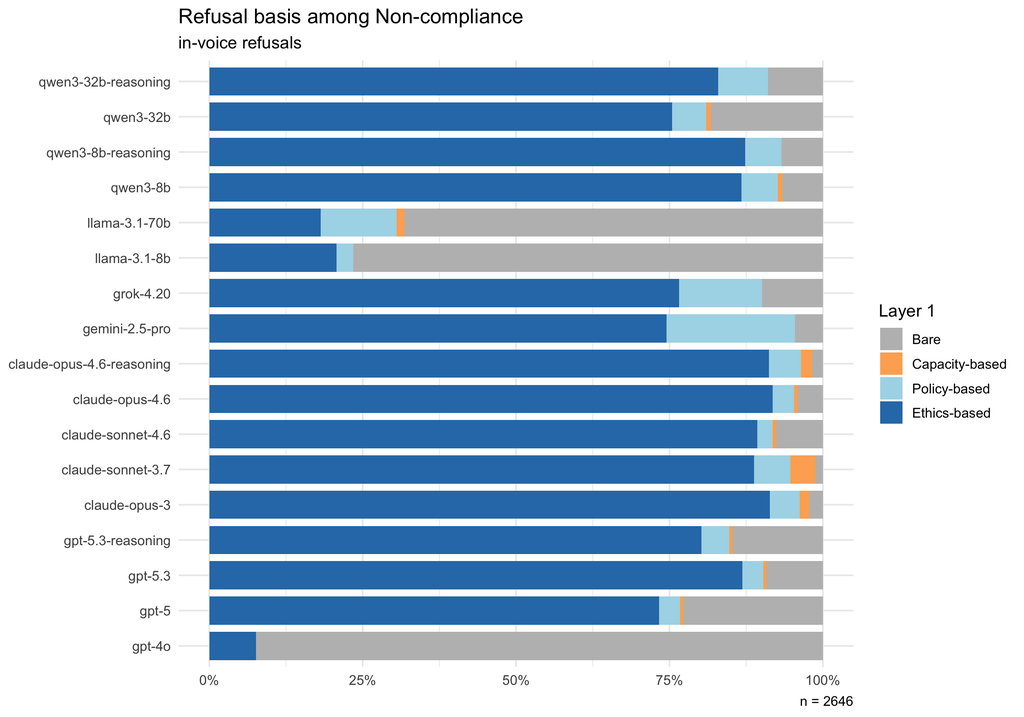

```r
l1_levels <- c("Bare", "Capacity-based", "Policy-based", "Ethics-based")
l1_pal    <- c("Bare" = "#bdbdbd",
               "Capacity-based" = "#fdae61",
               "Policy-based" = "#abd9e9",
               "Ethics-based" = "#2c7bb6")

l1_tbl <- df_nc |>
  filter(layer1 %in% l1_levels) |>
  count(model, layer1, family) |>
  group_by(model, family) |>
  mutate(prop = n / sum(n),
         layer1 = factor(layer1, levels = l1_levels)) |>
  ungroup()

ggplot(l1_tbl, aes(model, prop, fill = layer1)) +
  geom_col(width = 0.8) +
  scale_y_continuous(labels = percent_format(1)) +
  scale_fill_manual(values = l1_pal) +
  coord_flip() +
  labs(x = NULL, y = NULL, fill = "Layer 1",
       title = "Refusal basis among Non-compliance",
       subtitle = "in-voice refusals",
       caption = paste0("n = ", nrow(df_nc))) +
  theme_minimal(base_size = 12)
```

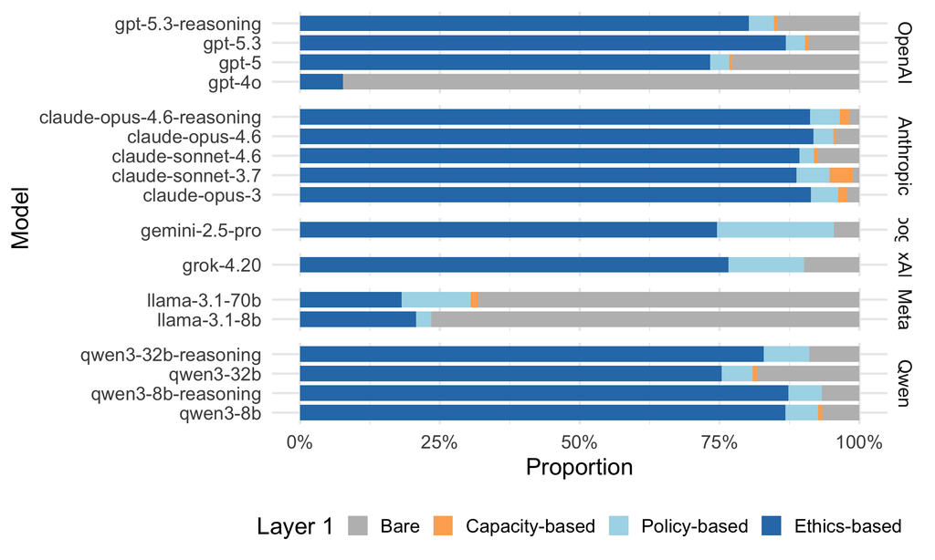

```r
## Paper: Figure 2?

ggplot(l1_tbl, aes(model, prop, fill = layer1)) +
  geom_col(width = 0.8) +
  scale_y_continuous(labels = percent_format(1)) +
  scale_fill_manual(values = l1_pal) +
  coord_flip() +
  labs(x = "Model", y = "Proportion", fill = "Layer 1") +
  theme_minimal(base_size = 18) +
  theme(
    legend.position = "bottom",
    ) +
  facet_grid(family ~., scales="free", space="free")
```

```r
# TODO: Fix facet labeller and move axis left

ggsave("figs/layer1_rx_invoice_refusals.pdf", width=8, height=7)
```

```r
df_nc |>
  filter(layer1 %in% l1_levels) |>
  count(model, layer1) |>
  group_by(model) |>
  mutate(pct = percent(n / sum(n), accuracy = 0.1)) |>
  select(model, layer1, n, pct) |>
  pivot_wider(names_from = layer1, values_from = c(n, pct), values_fill = list(n = 0, pct = "0%")) |>
  kable(caption = paste0("Layer 1 distribution by model")) |>
  kable_styling(bootstrap_options = c("striped", "hover"), font_size = 11)
```

Layer 1 distribution by model

| model | n_Bare | n_Ethics-based | n_Capacity-based | n_Policy-based | pct_Bare | pct_Ethics-based | pct_Capacity-based | pct_Policy-based |
| --- | --- | --- | --- | --- | --- | --- | --- | --- |
| gpt-4o | 145 | 12 | 0 | 0 | 92.4% | 7.6% | 0% | 0% |
| gpt-5 | 40 | 129 | 1 | 6 | 22.7% | 73.3% | 0.6% | 3.4% |
| gpt-5.3 | 16 | 152 | 1 | 6 | 9.1% | 86.9% | 0.6% | 3.4% |
| gpt-5.3-reasoning | 26 | 142 | 1 | 8 | 14.7% | 80.2% | 0.6% | 4.5% |
| claude-opus-3 | 4 | 169 | 3 | 9 | 2.2% | 91.4% | 1.6% | 4.9% |
| claude-sonnet-3.7 | 2 | 150 | 7 | 10 | 1.2% | 88.8% | 4.1% | 5.9% |
| claude-sonnet-4.6 | 12 | 142 | 1 | 4 | 7.5% | 89.3% | 0.6% | 2.5% |
| claude-opus-4.6 | 7 | 157 | 1 | 6 | 4.1% | 91.8% | 0.6% | 3.5% |
| claude-opus-4.6-reasoning | 3 | 155 | 3 | 9 | 1.8% | 91.2% | 1.8% | 5.3% |
| gemini-2.5-pro | 5 | 82 | 0 | 23 | 4.5% | 74.5% | 0% | 20.9% |
| grok-4.20 | 14 | 108 | 0 | 19 | 9.9% | 76.6% | 0% | 13.5% |
| llama-3.1-8b | 140 | 38 | 0 | 5 | 76.5% | 20.8% | 0% | 2.7% |
| llama-3.1-70b | 105 | 28 | 2 | 19 | 68.2% | 18.2% | 1.3% | 12.3% |
| qwen3-8b | 9 | 118 | 1 | 8 | 6.6% | 86.8% | 0.7% | 5.9% |
| qwen3-8b-reasoning | 9 | 117 | 0 | 8 | 6.7% | 87.3% | 0% | 6.0% |
| qwen3-32b | 23 | 95 | 1 | 7 | 18.3% | 75.4% | 0.8% | 5.6% |
| qwen3-32b-reasoning | 11 | 102 | 0 | 10 | 8.9% | 82.9% | 0% | 8.1% |

# 4. Layer 2: Form features (among Non-compliance)

## 4.1 Feature prevalence heatmap

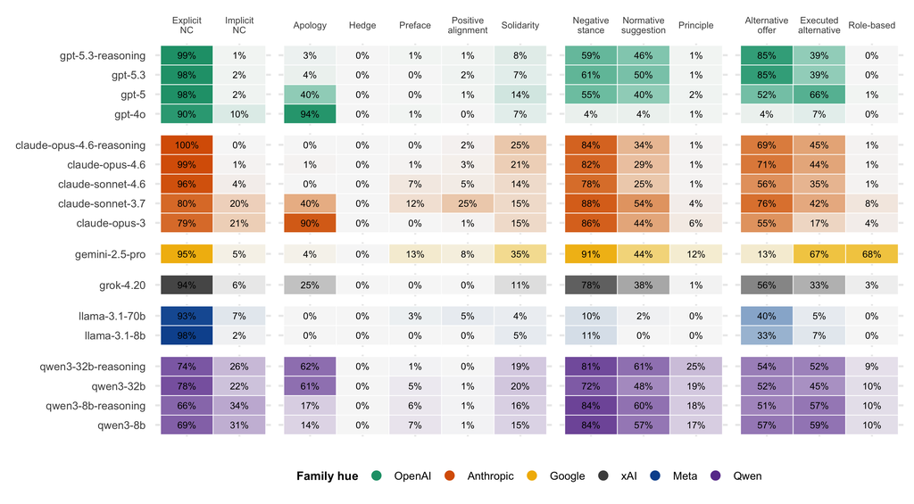

```r
l2_tbl <- df_nc |>
  select(model, family, all_of(L2_FEATURES)) |>
  pivot_longer(-c(model, family), names_to = "feature", values_to = "value") |>
  filter(!is.na(value)) |>
  group_by(model, family, feature) |>
  summarise(rate = mean(value), n = n(), .groups = "drop") |>
  mutate(
    feature = factor(feature, levels = L2_FEATURES),
    feature_group = factor(L2_FEATURE_GROUP[as.character(feature)], levels = L2_FEATURE_GROUP_LEVELS),
    family = factor(family, levels = names(FAMILY_PALETTE)),
    tile_fill = family_rate_colour(rate, family)
  )

family_legend <- tibble(
  family = factor(names(FAMILY_PALETTE), levels = names(FAMILY_PALETTE))
) |>
  mutate(
    feature = factor(L2_FEATURES[1], levels = L2_FEATURES),
    feature_group = factor(L2_FEATURE_GROUP[as.character(feature)], levels = L2_FEATURE_GROUP_LEVELS),
    model = map_chr(as.character(family), \(f) {
      as.character(l2_tbl$model[l2_tbl$family == f][1])
    }) |>
      factor(levels = levels(l2_tbl$model))
  )

ggplot(l2_tbl, aes(feature, model)) +
  geom_tile(aes(fill = tile_fill), colour = "white", linewidth = 0.4) +
  geom_text(aes(label = percent(rate, accuracy = 1)), size = 3.8, vjust = 0.5) +
  geom_point(
    data = family_legend,
    aes(feature, model, colour = family),
    inherit.aes = FALSE,
    alpha = 0,
    size = 3
  ) +
  scale_fill_identity(name = "Rate intensity") +
  scale_colour_manual(values = FAMILY_PALETTE, name = "Family hue") +
  scale_x_discrete(position = "top", labels = L2_FEATURE_LABELS, drop = TRUE) +
  facet_grid(family ~ feature_group, scales = "free", space = "free", switch = "y") +
  labs(x = NULL, y = NULL,
       # title = "Overall L2 feature distribution by model"
       ) +
  theme_minimal(base_size = 24) +
  theme(
    plot.title = element_text(face = "bold", size = 20),
    axis.text.x = element_text(size = 10.5, angle = 0, hjust = 0.5, vjust = 0.5, lineheight = 0.9),
    axis.text.y = element_text(size = 12.5),
    legend.title = element_text(size = 13.5, face = "bold"),
    legend.text = element_text(size = 12.5),
    legend.position = "bottom",
    strip.placement = "outside",
    strip.text.y.left = element_blank(),
    strip.text.x = element_blank(),
    strip.background.x = element_blank(),
    strip.background.y = element_blank(),
    panel.spacing = unit(0.6, "lines")
  ) +
  guides(colour = guide_legend(nrow = 1, override.aes = list(alpha = 1, size = 4)))
```

```r
ggsave("figs/layer2_model_heatmap.pdf", width = 14, height = 7, dpi = 300)
```

## 4.2 Cross-model spread in L2 strategies

`model feature rate - average feature rate across models`

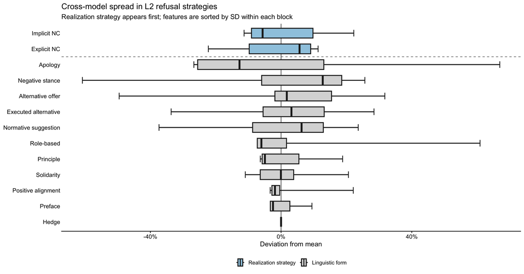

```r
l2_model_delta <- l2_tbl |>
  group_by(feature) |>
  mutate(
    feature_mean = mean(rate, na.rm = TRUE),
    feature_sd = sd(rate, na.rm = TRUE),
    delta = rate - feature_mean,
    strategy_type = factor(
      if_else(
        as.character(feature) %in% c("explicit_nc", "implicit_nc"),
        "Realization strategy",
        "Linguistic form"
      ),
      levels = c("Realization strategy", "Linguistic form")
    )
  ) |>
  ungroup()

l2_feature_spread <- l2_model_delta |>
  group_by(feature) |>
  summarise(
    mean_rate = mean(rate, na.rm = TRUE),
    sd_rate = sd(rate, na.rm = TRUE),
    min_rate = min(rate, na.rm = TRUE),
    max_rate = max(rate, na.rm = TRUE),
    range_rate = max_rate - min_rate,
    q1_delta = quantile(delta, 0.25, na.rm = TRUE),
    median_delta = median(delta, na.rm = TRUE),
    q3_delta = quantile(delta, 0.75, na.rm = TRUE),
    min_delta = min(delta, na.rm = TRUE),
    max_delta = max(delta, na.rm = TRUE),
    .groups = "drop"
  ) |>
  mutate(
    strategy_type = factor(
      if_else(
        as.character(feature) %in% c("explicit_nc", "implicit_nc"),
        "Realization strategy",
        "Linguistic form"
      ),
      levels = c("Realization strategy", "Linguistic form")
    ),
    block_order = if_else(strategy_type == "Realization strategy", 1L, 2L)
  ) |>
  arrange(block_order, desc(sd_rate)) |>
  mutate(feature_rank = row_number())

l2_spread_order <- as.character(l2_feature_spread$feature)

l2_model_delta <- l2_model_delta |>
  mutate(feature = factor(as.character(feature), levels = l2_spread_order))

l2_feature_spread <- l2_feature_spread |>
  mutate(feature = factor(as.character(feature), levels = l2_spread_order))

realization_separator_y <- length(l2_spread_order) - sum(l2_feature_spread$strategy_type == "Realization strategy") + 0.5

ggplot(l2_model_delta, aes(x = delta, y = fct_rev(feature), group = feature, fill = strategy_type)) +
  geom_hline(yintercept = realization_separator_y, linetype = "dashed",
             colour = "grey45", linewidth = 0.45) +
  geom_vline(xintercept = 0, colour = "grey35", linewidth = 0.55) +
  stat_boxplot(geom = "errorbar", coef = 1000, orientation = "y",
               width = 0.42, colour = "#222222", linewidth = 0.65) +
  geom_boxplot(coef = 1000, orientation = "y", width = 0.62,
               colour = "#222222",
               linewidth = 0.8, outlier.shape = NA) +
  scale_x_continuous(labels = percent_format(1)) +
  scale_y_discrete(labels = \(x) str_replace_all(L2_FEATURE_LABELS[x], "\n", " ")) +
  scale_fill_manual(
    values = c("Realization strategy" = "#9ecae1", "Linguistic form" = "#d9d9d9"),
    name = NULL
  ) +
  labs(x = "Deviation from mean", y = NULL,
       title = "Cross-model spread in L2 refusal strategies",
       subtitle = "Realization strategy appears first; features are sorted by SD within each block") +
  theme_classic(base_size = 12) +
  theme(
    axis.text.y = element_text(size = 10.5),
    axis.text.x = element_text(size = 10.5),
    axis.line.y = element_blank(),
    axis.ticks.y = element_blank(),
    legend.position = "bottom"
  )
```

```r
ggsave("figs/layer2_strategy_spread.pdf", width = 7, height = 7, dpi = 300)
```

```r
l2_feature_spread |>
  arrange(desc(sd_rate)) |>
  mutate(
    feature = str_replace_all(as.character(L2_FEATURE_LABELS[as.character(feature)]), "\n", " "),
    across(c(sd_rate, min_delta, q1_delta, median_delta, q3_delta, max_delta),
           \(x) percent(x, accuracy = 0.1))
  ) |>
  select(feature, sd_rate, min_delta, q1_delta, median_delta, q3_delta, max_delta) |>
  kable(
    col.names = c("Feature", "SD of spread", "Min", "Q1", "Median", "Q3", "Max"),
    caption = "Boxplot statistics for model-level deviation around each feature's mean rate."
  ) |>
  kable_styling(bootstrap_options = c("striped", "hover"), font_size = 11, full_width = FALSE)
```

Boxplot statistics for model-level deviation around each feature’s mean rate.

| Feature | SD of spread | Min | Q1 | Median | Q3 | Max |
| --- | --- | --- | --- | --- | --- | --- |
| Apology | 32.2% | -26.7% | -25.5% | -12.7% | 13.1% | 66.9% |
| Negative stance | 28.9% | -60.8% | -5.9% | 12.8% | 18.6% | 25.6% |
| Alternative offer | 22.1% | -49.6% | -1.9% | 1.8% | 15.4% | 31.8% |
| Executed alternative | 19.8% | -33.6% | -5.5% | 3.2% | 13.2% | 28.4% |
| Normative suggestion | 19.6% | -37.4% | -8.7% | 6.3% | 12.9% | 23.6% |
| Role-based | 16.2% | -7.3% | -7.3% | -6.0% | 1.7% | 60.9% |
| Implicit NC | 11.5% | -11.3% | -9.1% | -5.7% | 9.8% | 22.3% |
| Explicit NC | 11.5% | -22.3% | -9.8% | 5.7% | 9.1% | 11.3% |
| Principle | 8.4% | -6.4% | -5.8% | -4.9% | 5.5% | 18.8% |
| Solidarity | 7.8% | -10.9% | -6.4% | -0.1% | 3.9% | 20.6% |
| Positive alignment | 6.1% | -3.3% | -2.8% | -1.9% | -0.4% | 22.1% |
| Preface | 4.3% | -3.3% | -3.3% | -2.5% | 2.7% | 9.4% |
| Hedge | 0.0% | 0.0% | 0.0% | 0.0% | 0.0% | 0.0% |

```r
l2_extremes <- bind_rows(
  l2_model_delta |>
    group_by(feature) |>
    slice_max(delta, n = 1, with_ties = FALSE) |>
    ungroup() |>
    mutate(extreme = "highest above average"),
  l2_model_delta |>
    group_by(feature) |>
    slice_min(delta, n = 1, with_ties = FALSE) |>
    ungroup() |>
    mutate(extreme = "lowest below average")
) |>
  arrange(feature, desc(delta)) |>
  mutate(
    feature = str_replace_all(as.character(L2_FEATURE_LABELS[as.character(feature)]), "\n", " "),
    rate = percent(rate, accuracy = 0.1),
    feature_mean = percent(feature_mean, accuracy = 0.1),
    delta = percent(delta, accuracy = 0.1)
  ) |>
  select(feature, extreme, model, rate, feature_mean, delta)

l2_extremes |>
  kable(
    col.names = c("Feature", "Extreme", "Model", "Model rate", "Feature average", "Difference"),
    caption = "Most extreme model-level deviations for each L2 feature."
  ) |>
  kable_styling(bootstrap_options = c("striped", "hover"), font_size = 11, full_width = FALSE)
```

Most extreme model-level deviations for each L2 feature.

| Feature | Extreme | Model | Model rate | Feature average | Difference |
| --- | --- | --- | --- | --- | --- |
| Implicit NC | highest above average | qwen3-8b-reasoning | 33.6% | 11.3% | 22.3% |
| Implicit NC | lowest below average | claude-opus-4.6-reasoning | 0.0% | 11.3% | -11.3% |
| Explicit NC | highest above average | claude-opus-4.6-reasoning | 100.0% | 88.7% | 11.3% |
| Explicit NC | lowest below average | qwen3-8b-reasoning | 66.4% | 88.7% | -22.3% |
| Apology | highest above average | gpt-4o | 93.6% | 26.7% | 66.9% |
| Apology | lowest below average | claude-sonnet-4.6 | 0.0% | 26.7% | -26.7% |
| Negative stance | highest above average | gemini-2.5-pro | 90.9% | 65.3% | 25.6% |
| Negative stance | lowest below average | gpt-4o | 4.5% | 65.3% | -60.8% |
| Alternative offer | highest above average | gpt-5.3 | 85.1% | 53.4% | 31.8% |
| Alternative offer | lowest below average | gpt-4o | 3.8% | 53.4% | -49.6% |
| Executed alternative | highest above average | gemini-2.5-pro | 67.3% | 38.8% | 28.4% |
| Executed alternative | lowest below average | llama-3.1-70b | 5.2% | 38.8% | -33.6% |
| Normative suggestion | highest above average | qwen3-32b-reasoning | 61.0% | 37.4% | 23.6% |
| Normative suggestion | lowest below average | llama-3.1-8b | 0.0% | 37.4% | -37.4% |
| Role-based | highest above average | gemini-2.5-pro | 68.2% | 7.3% | 60.9% |
| Role-based | lowest below average | gpt-4o | 0.0% | 7.3% | -7.3% |
| Principle | highest above average | qwen3-32b-reasoning | 25.2% | 6.4% | 18.8% |
| Principle | lowest below average | llama-3.1-8b | 0.0% | 6.4% | -6.4% |
| Solidarity | highest above average | gemini-2.5-pro | 35.5% | 14.8% | 20.6% |
| Solidarity | lowest below average | llama-3.1-70b | 3.9% | 14.8% | -10.9% |
| Positive alignment | highest above average | claude-sonnet-3.7 | 25.4% | 3.3% | 22.1% |
| Positive alignment | lowest below average | gpt-4o | 0.0% | 3.3% | -3.3% |
| Preface | highest above average | gemini-2.5-pro | 12.7% | 3.3% | 9.4% |
| Preface | lowest below average | gpt-5 | 0.0% | 3.3% | -3.3% |
| Hedge | highest above average | gpt-4o | 0.0% | 0.0% | 0.0% |
| Hedge | lowest below average | gpt-4o | 0.0% | 0.0% | 0.0% |

## 4.3 Apology decay across OpenAI and Claude releases

This view focuses only on the `apology` feature among in-voice refusals. The timeline uses public release dates where available. Reasoning variants are omitted from the main plot because they are mode/configuration variants of the same underlying release rather than separate model generations.

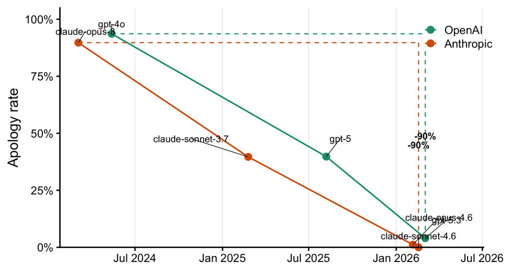

```r
MODEL_RELEASE_DATES <- tribble(
  ~model,                ~family,      ~release_date, ~release_source,
  "gpt-4o",              "OpenAI",     "2024-05-13", "OpenAI GPT-4o announcement",
  "gpt-5",               "OpenAI",     "2025-08-07", "OpenAI GPT-5 announcement",
  "gpt-5.3",             "OpenAI",     "2026-03-03", "OpenAI GPT-5.3 Instant announcement",
  "claude-opus-3",       "Anthropic",  "2024-03-04", "Anthropic Claude 3 Opus announcement",
  "claude-sonnet-3.7",   "Anthropic",  "2025-02-24", "Anthropic Claude 3.7 Sonnet announcement",
  "claude-opus-4.6",     "Anthropic",  "2026-02-05", "Anthropic Claude Opus 4.6 announcement",
  "claude-sonnet-4.6",   "Anthropic",  "2026-02-17", "Anthropic Claude Sonnet 4.6 announcement"
) |>
  mutate(
    release_date = as.Date(release_date),
    model = factor(model, levels = MODEL_ORDER),
    family = factor(family, levels = c("OpenAI", "Anthropic"))
  )

apology_timeline <- df_nc |>
  filter(as.character(model) %in% as.character(MODEL_RELEASE_DATES$model),
         !is.na(apology)) |>
  group_by(model, family) |>
  summarise(apology_rate = mean(apology), n = n(), .groups = "drop") |>
  left_join(MODEL_RELEASE_DATES, by = c("model", "family"))

apology_events <- apology_timeline |>
  arrange(release_date, family) |>
  mutate(
    point_label = as.character(model),
    label_x = case_when(
      as.character(model) == "claude-opus-3" ~ release_date + lubridate::days(15),
      as.character(model) == "gpt-4o" ~ release_date,
      as.character(model) == "gpt-5" ~ release_date + lubridate::days(30),
      as.character(model) == "gpt-5.3" ~ release_date + lubridate::days(45),
      as.character(model) == "claude-sonnet-3.7" ~ release_date - lubridate::days(120),
      as.character(model) == "claude-opus-4.6" ~ release_date + lubridate::days(55),
      as.character(model) == "claude-sonnet-4.6" ~ release_date,
      TRUE ~ release_date
    ),
    label_y = case_when(
      as.character(model) == "claude-opus-3" ~ apology_rate + 0.05,
      as.character(model) == "gpt-4o" ~ 0.98,
      as.character(model) == "gpt-5" ~ apology_rate + 0.08,
      as.character(model) == "gpt-5.3" ~ apology_rate + 0.08,
      as.character(model) == "claude-sonnet-3.7" ~ apology_rate + 0.08,
      as.character(model) == "claude-opus-4.6" ~ apology_rate + 0.12,
      as.character(model) == "claude-sonnet-4.6" ~ apology_rate + 0.05,
      TRUE ~ apology_rate + 0.08
    )
  )

apology_decay_endpoints <- apology_events |>
  group_by(family) |>
  arrange(release_date, .by_group = TRUE) |>
  summarise(
    x_start = first(release_date),
    x_end = last(release_date),
    y_start = first(apology_rate),
    y_end = last(apology_rate),
    change_label = paste0(if_else(y_end - y_start < 0, "", "+"),
                          percent(y_end - y_start, accuracy = 1)),
    .groups = "drop"
  )

ggplot(apology_events, aes(release_date, apology_rate, colour = family)) +
  geom_line(aes(group = family), linewidth = 0.9) +
  geom_segment(
    data = apology_decay_endpoints,
    aes(x = x_start, xend = x_end, y = y_start, yend = y_start, colour = family),
    inherit.aes = FALSE,
    linetype = "dashed",
    linewidth = 0.65
  ) +
  geom_segment(
    data = apology_decay_endpoints,
    aes(x = x_end, xend = x_end, y = y_start, yend = y_end, colour = family),
    inherit.aes = FALSE,
    linetype = "dashed",
    linewidth = 0.65
  ) +
  geom_point(size = 3.6) +
  geom_segment(aes(x = label_x, xend = release_date, y = label_y, yend = apology_rate),
               colour = "black", linewidth = 0.35, show.legend = FALSE) +
  geom_text(aes(x = label_x, y = label_y, label = point_label),
            colour = "black", size = 4.2, lineheight = 0.9, show.legend = FALSE) +
  geom_text(
    data = apology_decay_endpoints,
    aes(x = x_end, y = (y_start + y_end) / 2, label = change_label),
    inherit.aes = FALSE,
    hjust = 0.5,
    size = 4.2,
    fontface = "bold",
    colour = "black"
  ) +
  scale_x_date(
    date_breaks = "6 months",
    date_labels = "%b %Y",
    expand = expansion(mult = c(0.05, 0.1))
  ) +
  scale_y_continuous(labels = percent_format(1),
                     expand = expansion(mult = c(0, 0.05))) +
  scale_colour_manual(values = c(OpenAI = "#1b9e77", Anthropic = "#d95f02"),
                      labels = c(OpenAI = "OpenAI", Anthropic = "Anthropic")) +
  coord_cartesian(ylim = c(0, 1), clip = "off") +
  labs(x = NULL,
       y = "Apology rate", colour = NULL) +
  theme_classic(base_size = 18) +
  theme(
    legend.position = c(0.94, 0.88),
    legend.background = element_blank(),
    plot.margin = margin(t = 10, r = 35, b = 10, l = 10),
    panel.grid.major.x = element_line(colour = "grey88", linewidth = 0.3)
  )
```

```r
ggsave("figs/apology_decay_timeline.pdf", width = 7, height = 7, dpi = 300)
```

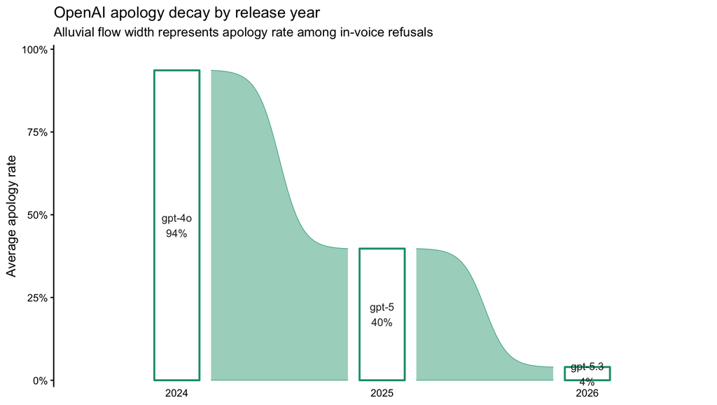

```r
openai_apology_yearly <- apology_timeline |>
  filter(family == "OpenAI") |>
  mutate(release_year = lubridate::year(release_date)) |>
  group_by(release_year) |>
  summarise(
    apology_rate = weighted.mean(apology_rate, w = n),
    n_models = n(),
    n_refusals = sum(n),
    models = paste(as.character(model), collapse = ", "),
    .groups = "drop"
  ) |>
  arrange(release_year) |>
  mutate(
    next_year = lead(release_year),
    next_rate = lead(apology_rate),
    change = next_rate - apology_rate,
    abs_change = abs(change),
    node_label = paste0(models, "\n", percent(apology_rate, accuracy = 1))
  )

openai_alluvial <- openai_apology_yearly |>
  transmute(
    family = "OpenAI",
    axis = factor(release_year, levels = c(2024, 2025, 2026)),
    model_node = paste0(models, "\n", percent(apology_rate, accuracy = 1)),
    apology_rate
  )

ggplot(openai_alluvial,
       aes(x = axis, stratum = model_node, alluvium = family,
           y = apology_rate, fill = family, label = model_node)) +
  ggalluvial::geom_flow(alpha = 0.45, curve_type = "sigmoid",
                        colour = "#1b9e77", linewidth = 0.2) +
  ggalluvial::geom_stratum(width = 0.22, colour = "#1b9e77",
                           fill = "white", linewidth = 0.8) +
  geom_text(stat = "stratum", size = 3.2, colour = "grey15") +
  scale_y_continuous(labels = percent_format(1),
                     expand = expansion(mult = c(0.02, 0.08))) +
  scale_fill_manual(values = c(OpenAI = "#1b9e77"), guide = "none") +
  labs(x = NULL, y = "Average apology rate",
       title = "OpenAI apology decay by release year",
       subtitle = "Alluvial flow width represents apology rate among in-voice refusals") +
  theme_classic(base_size = 11) +
  theme(
    axis.line.x = element_blank(),
    axis.ticks.x = element_blank()
  )
```

```r
ggsave("figs/apology_decay_openai_alluvial.pdf", width = 9, height = 5, dpi = 300)
```

```r
apology_timeline |>
  arrange(family, release_date) |>
  mutate(
    release_date = format(release_date, "%Y-%m-%d"),
    apology_rate = percent(apology_rate, accuracy = 0.1)
  ) |>
  select(family, model, release_date, n, apology_rate, release_source) |>
  kable(
    col.names = c("Family", "Model", "Release date", "n in-voice NC", "Apology rate", "Release-date source"),
    caption = "Apology-rate timeline inputs. Release dates are encoded from public model announcements."
  ) |>
  kable_styling(bootstrap_options = c("striped", "hover"), font_size = 11, full_width = FALSE)
```

Apology-rate timeline inputs. Release dates are encoded from public model announcements.

| Family | Model | Release date | n in-voice NC | Apology rate | Release-date source |
| --- | --- | --- | --- | --- | --- |
| OpenAI | gpt-4o | 2024-05-13 | 157 | 93.6% | OpenAI GPT-4o announcement |
| OpenAI | gpt-5 | 2025-08-07 | 176 | 39.8% | OpenAI GPT-5 announcement |
| OpenAI | gpt-5.3 | 2026-03-03 | 175 | 4.0% | OpenAI GPT-5.3 Instant announcement |
| Anthropic | claude-opus-3 | 2024-03-04 | 185 | 89.7% | Anthropic Claude 3 Opus announcement |
| Anthropic | claude-sonnet-3.7 | 2025-02-24 | 169 | 39.6% | Anthropic Claude 3.7 Sonnet announcement |
| Anthropic | claude-opus-4.6 | 2026-02-05 | 171 | 1.2% | Anthropic Claude Opus 4.6 announcement |
| Anthropic | claude-sonnet-4.6 | 2026-02-17 | 159 | 0.0% | Anthropic Claude Sonnet 4.6 announcement |

Takehomes:

Overall: Gemini is v interesting. Lots of aligning/affiliative features but also lots of negative stance, Should find examples

Follow up q’s: - Why are models (e.g. qwen) implicit vs explicit? What predicts it? Harm category? - What correlates with apologies for “sometimes apologisers”?

## 5.4 L2 features by category (selected)

All judged in-voice refusals. Which categories elicit hedging, solidarity, and normative suggestion?

Grouping note: this selected-feature view is useful for scanning, but it should probably not carry the main claim. The difference-scale graph in 5.5 and the grouped harm-tier view in 5.6.2 are cleaner candidates for paper figures.

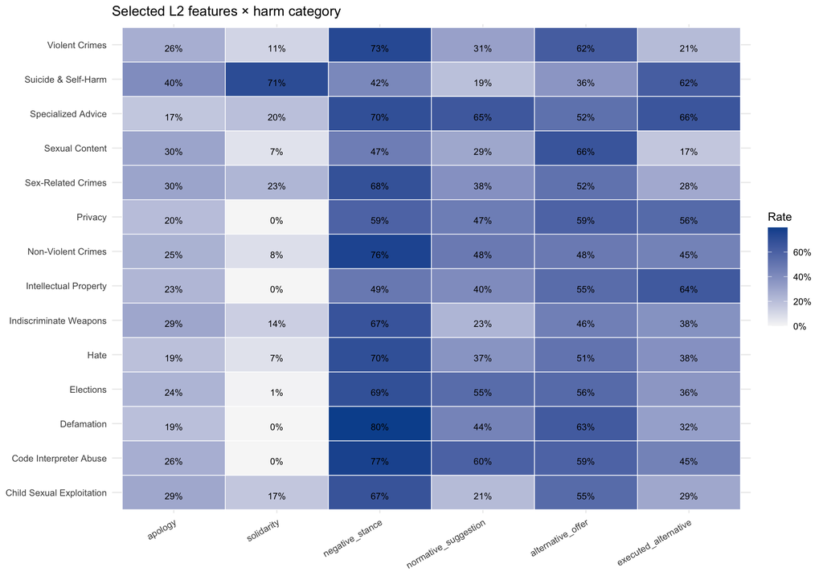

```r
selected_features <- c("apology", "solidarity", "negative_stance",
                       "normative_suggestion", "alternative_offer", "executed_alternative")

df_nc |>
  select(primary_llama_guard_category_name, all_of(selected_features)) |>
  pivot_longer(-primary_llama_guard_category_name, names_to = "feature", values_to = "value") |>
  filter(!is.na(value)) |>
  group_by(primary_llama_guard_category_name, feature) |>
  summarise(rate = mean(value), .groups = "drop") |>
  mutate(feature = factor(feature, levels = selected_features)) |>
  ggplot(aes(feature, primary_llama_guard_category_name, fill = rate)) +
    geom_tile(colour = "white", linewidth = 0.3) +
    geom_text(aes(label = percent(rate, accuracy = 1)), size = 2.8, vjust = 1) +
    scale_fill_gradient(low = "#f7f7f7", high = "#08519c",
                        labels = percent_format(1)) +
    labs(x = NULL, y = NULL, fill = "Rate",
         title = "Selected L2 features × harm category") +
    theme_minimal(base_size = 10) +
    theme(axis.text.x = element_text(angle = 30, hjust = 1))
```

## 5.5 Full model × L2 feature × harm category

Every cell is the rate of a given L2 feature among that model’s NC responses within that harm category. Cells with fewer than `MIN_CELL_N` NC observations are masked to grey, because rates over very small denominators are not meaningful. Split across two figures to stay legible.

```r
MIN_CELL_N <- 3

l2_mod_cat <- df_nc |>
  select(model,
         category = primary_llama_guard_category_name,
         all_of(L2_FEATURES)) |>
  pivot_longer(-c(model, category), names_to = "feature", values_to = "value") |>
  filter(!is.na(value)) |>
  group_by(model, category, feature) |>
  summarise(rate = mean(value), n = n(), .groups = "drop") |>
  mutate(rate = if_else(n < MIN_CELL_N, NA_real_, rate),
         feature = factor(feature, levels = L2_FEATURES))

# Order categories by their pooled refusal rate (high → low) so the most
# refusal-heavy categories appear first in the split.
cat_order <- df_clean |>
  group_by(primary_llama_guard_category_name) |>
  summarise(rr = mean(layer0 == "Non-compliance"), .groups = "drop") |>
  arrange(desc(rr)) |>
  pull(primary_llama_guard_category_name)

l2_mod_cat <- l2_mod_cat |>
  mutate(category = factor(category, levels = cat_order))

cat_part1 <- cat_order[1:7]
cat_part2 <- cat_order[8:length(cat_order)]
```

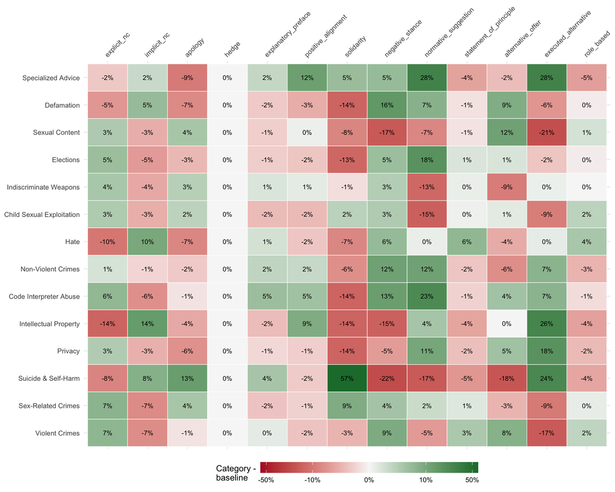

```r
l2_cat_delta <- df_nc |>
  select(category = primary_llama_guard_category_name, all_of(L2_FEATURES)) |>
  pivot_longer(-category, names_to = "feature", values_to = "value") |>
  filter(!is.na(value)) |>
  group_by(feature) |>
  mutate(feature_baseline = mean(value)) |>
  group_by(category, feature, feature_baseline) |>
  summarise(rate = mean(value), n = n(), .groups = "drop") |>
  mutate(
    delta = rate - feature_baseline,
    feature = factor(feature, levels = L2_FEATURES),
    category = factor(category, levels = cat_order)
  )

signed_log_delta <- function(x, sigma = 0.02) {
  sign(x) * log1p(abs(x) / sigma)
}

delta_breaks_raw <- c(-0.50, -0.10, 0, 0.10, 0.50)
delta_limit <- signed_log_delta(0.60)

l2_cat_delta <- l2_cat_delta |>
  mutate(delta_colour = signed_log_delta(delta))

p_l2_harm_difference <- ggplot(l2_cat_delta, aes(feature, category, fill = delta_colour)) +
  geom_tile(colour = "white", linewidth = 0.25) +
  geom_text(aes(label = percent(delta, accuracy = 1)), size = 2.7) +
  scale_fill_gradient2(
    low = "#b2182b",
    mid = "#f7f7f7",
    high = "#1b7837",
    midpoint = 0,
    limits = c(-delta_limit, delta_limit),
    breaks = signed_log_delta(delta_breaks_raw),
    labels = percent(delta_breaks_raw, accuracy = 1),
    name = "Category -\nbaseline"
  ) +
  scale_x_discrete(position = "top") +
  labs(x = NULL, y = NULL) +
  theme_minimal(base_size = 10) +
  theme(axis.text.x = element_text(angle = 45, hjust = 0, vjust = 0),
        legend.position = "bottom") +
  guides(fill = guide_colourbar(
    title.position = "left",
    title.vjust = 0.5,
    barwidth = unit(9, "cm"),
    barheight = unit(0.45, "cm")
  ))

p_l2_harm_difference
```

```r
ggsave("figs/l2_harm_difference_scale.pdf", plot = p_l2_harm_difference, width = 7, height = 7, dpi = 300)
```

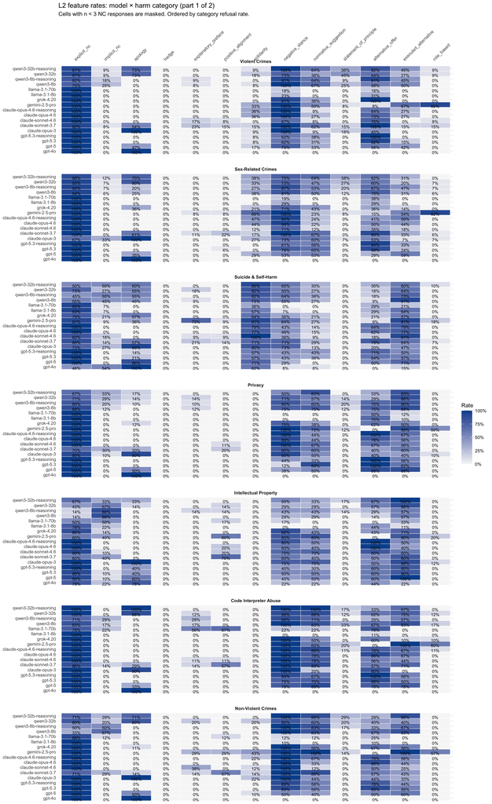

```r
ggplot(filter(l2_mod_cat, category %in% cat_part1),
       aes(feature, model, fill = rate)) +
  geom_tile(colour = "white", linewidth = 0.2) +
  geom_text(aes(label = if_else(is.na(rate), "", percent(rate, accuracy = 1))),
            size = 2.4, vjust = 1) +
  facet_wrap(~ category, ncol = 1) +
  scale_fill_gradient(low = "#f7f7f7", high = "#08519c",
                      na.value = "grey92",
                      labels = percent_format(1), name = "Rate") +
  scale_x_discrete(position = "top") +
  labs(x = NULL, y = NULL,
       title = "L2 feature rates: model × harm category (part 1 of 2)",
       subtitle = paste0("Cells with n < ", MIN_CELL_N,
                         " NC responses are masked. Ordered by category refusal rate.")) +
  theme_minimal(base_size = 9) +
  theme(axis.text.x = element_text(angle = 45, hjust = 0, vjust = -0.2),
        strip.text = element_text(face = "bold"),
        panel.spacing.y = unit(1.2, "lines"))
```

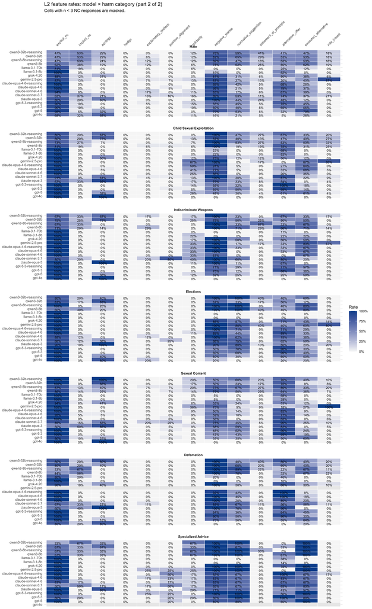

```r
ggplot(filter(l2_mod_cat, category %in% cat_part2),
       aes(feature, model, fill = rate)) +
  geom_tile(colour = "white", linewidth = 0.2) +
  geom_text(aes(label = if_else(is.na(rate), "", percent(rate, accuracy = 1))),
            size = 2.4, vjust = 1) +
  facet_wrap(~ category, ncol = 1) +
  scale_fill_gradient(low = "#f7f7f7", high = "#08519c",
                      na.value = "grey92",
                      labels = percent_format(1), name = "Rate") +
  scale_x_discrete(position = "top") +
  labs(x = NULL, y = NULL,
       title = "L2 feature rates: model × harm category (part 2 of 2)",
       subtitle = paste0("Cells with n < ", MIN_CELL_N,
                         " NC responses are masked.")) +
  theme_minimal(base_size = 9) +
  theme(axis.text.x = element_text(angle = 45, hjust = 0, vjust = -0.2),
        strip.text = element_text(face = "bold"),
        panel.spacing.y = unit(1.2, "lines"))
```

## 5.6 Richer visualization ideas

The full model × category × feature heatmap is information-dense but visually noisy. The views below are prototypes for higher-signal alternatives. All use the full judged in-voice refusal set.

### 5.6.1 Aggregated feature families

The 11 substantive L2 features (excluding `explicit_nc`/`implicit_nc` — see note below) collapse into four interpretable bundles. A response scores 1 on a bundle if **any** of its constituent features is 1 (OR rule); the bundle rate is then the proportion of refusals with at least one of the features present.

```r
FEATURE_FAMILY <- list(
  rapport    = c("solidarity", "positive_alignment"),
  concessive = c("apology", "hedge", "explanatory_preface", "role_based"),
  normative  = c("normative_suggestion", "negative_stance", "statement_of_principle"),
  helpful    = c("alternative_offer", "executed_alternative")
)

FEATURE_FAMILY_DESC <- tribble(
  ~bundle,       ~gloss,                                                              ~features,
  "rapport",     "Rapport-building — explicitly aligns with or stands with the user.", paste(FEATURE_FAMILY$rapport,    collapse = ", "),
  "concessive",  "Concessive / softening — yields ground, hedges, or distances the refusal.", paste(FEATURE_FAMILY$concessive, collapse = ", "),
  "normative",   "Normative / position-taking — asserts what the model takes to be right.",   paste(FEATURE_FAMILY$normative,  collapse = ", "),
  "helpful",     "Substitution / redirection — what the model offers instead.",        paste(FEATURE_FAMILY$helpful,    collapse = ", ")
)

FEATURE_FAMILY_DESC |>
  kable(caption = "Four L2-feature bundles used in 5.6.1 and 5.6.3.") |>
  kable_styling(bootstrap_options = c("striped","hover"), font_size = 11, full_width = FALSE)
```

Four L2-feature bundles used in 5.6.1 and 5.6.3.

| bundle | gloss | features |
| --- | --- | --- |
| rapport | Rapport-building — explicitly aligns with or stands with the user. | solidarity, positive_alignment |
| concessive | Concessive / softening — yields ground, hedges, or distances the refusal. | apology, hedge, explanatory_preface, role_based |
| normative | Normative / position-taking — asserts what the model takes to be right. | normative_suggestion, negative_stance, statement_of_principle |
| helpful | Substitution / redirection — what the model offers instead. | alternative_offer, executed_alternative |

`explicit_nc` and `implicit_nc` are mutually exclusive surface forms of the refusal act itself (they sum to 1 across NC responses), so they’re shown separately rather than folded into a bundle.

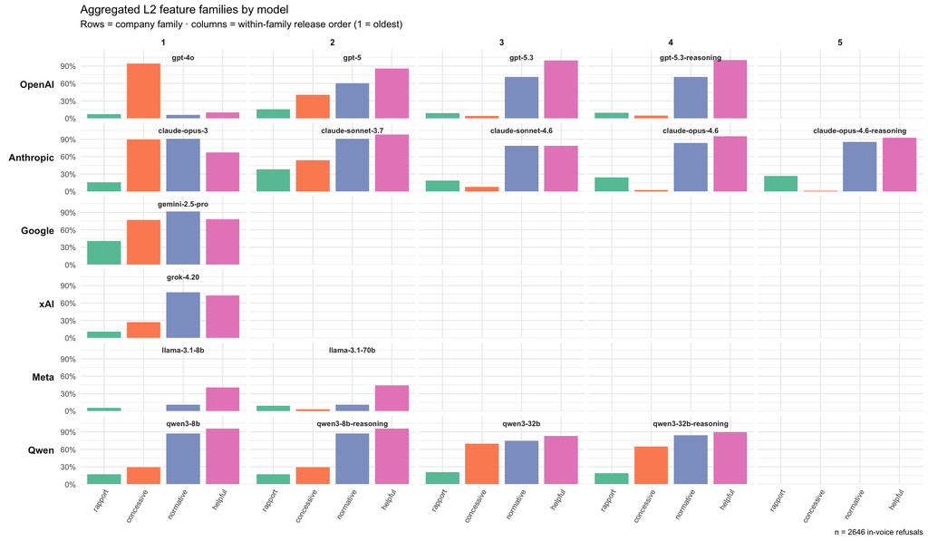

```r
family_long <- df_nc |>
  select(model, family, all_of(L2_FEATURES)) |>
  mutate(across(all_of(L2_FEATURES), as.numeric)) |>
  rowwise() |>
  mutate(
    rapport    = as.integer(any(c_across(all_of(FEATURE_FAMILY$rapport))    == 1, na.rm = TRUE)),
    concessive = as.integer(any(c_across(all_of(FEATURE_FAMILY$concessive)) == 1, na.rm = TRUE)),
    normative  = as.integer(any(c_across(all_of(FEATURE_FAMILY$normative))  == 1, na.rm = TRUE)),
    helpful    = as.integer(any(c_across(all_of(FEATURE_FAMILY$helpful))    == 1, na.rm = TRUE))
  ) |>
  ungroup() |>
  select(model, family, rapport, concessive, normative, helpful) |>
  pivot_longer(-c(model, family), names_to = "feature_family", values_to = "value") |>
  group_by(model, family, feature_family) |>
  summarise(rate = mean(value, na.rm = TRUE), .groups = "drop") |>
  mutate(feature_family = factor(feature_family,
                                 levels = c("rapport","concessive","normative","helpful")))

# Within-family release rank from MODEL_ORDER (which is already family→oldest→newest)
release_rank <- tibble(model = MODEL_ORDER) |>
  mutate(family = factor(MODEL_FAMILY[model],
                         levels = c("OpenAI","Anthropic","Google","xAI","Meta","Qwen"))) |>
  group_by(family) |>
  mutate(release_rank = row_number()) |>
  ungroup()

family_long_ranked <- family_long |>
  inner_join(select(release_rank, model, release_rank), by = "model") |>
  mutate(release_rank = factor(release_rank))

# Per-cell model name labels (one per facet cell)
cell_labels <- release_rank |>
  filter(model %in% unique(family_long$model)) |>
  mutate(release_rank = factor(release_rank))

ggplot(family_long_ranked, aes(feature_family, rate, fill = feature_family)) +
  geom_col(width = 0.85) +
  geom_text(
    data = cell_labels,
    aes(x = 3, y = 1.05, label = model),
    inherit.aes = FALSE,
    size = 2.4, fontface = "bold", color = "grey20"
  ) +
  facet_grid(family ~ release_rank,
             scales = "free_x", space = "free_x", switch = "y") +
  scale_y_continuous(labels = percent_format(1),
                     limits = c(0, 1.18),
                     expand = expansion(mult = c(0, 0))) +
  scale_fill_brewer(palette = "Set2") +
  labs(x = NULL, y = NULL, fill = NULL,
       title = "Aggregated L2 feature families by model",
       subtitle = "Rows = company family · columns = within-family release order (1 = oldest)",
       caption = paste0("n = ", nrow(df_nc), " in-voice refusals")) +
  theme_minimal(base_size = 9) +
  theme(
    axis.text.x  = element_text(angle = 60, hjust = 1, vjust = 1, size = 7),
    strip.text.y.left = element_text(angle = 0, face = "bold", hjust = 1, size = 9),
    strip.text.x = element_text(face = "bold", size = 8),
    strip.placement = "outside",
    panel.spacing.x = unit(0.2, "lines"),
    panel.spacing.y = unit(0.3, "lines"),
    legend.position = "none"
  )
```

### 5.6.2 Human harm labels vs model refusal rates

The graph below keeps the observed overall in-voice Non-compliance rate on the x-axis, but colors categories by the team’s human/normative harm grouping. This makes the mismatch visible: model refusal propensity does not cleanly track the human severity labels.

```r
TIER_LEVELS <- c("high", "med", "low", "self-harm")
TIER_PALETTE <- c(
  high = "#c0392b",
  med = "#d99a2b",
  low = "#4f8f7b",
  `self-harm` = "#7b6f8e"
)

HUMAN_HARM_TIER <- c(
  "Child Sexual Exploitation" = "high",
  "Indiscriminate Weapons"    = "high",
  "Violent Crimes"            = "high",
  "Hate"                      = "high",
  "Sex-Related Crimes"        = "high",
  "Defamation"                = "med",
  "Privacy"                   = "med",
  "Sexual Content"            = "med",
  "Non-Violent Crimes"        = "med",
  "Specialized Advice"        = "low",
  "Intellectual Property"     = "low",
  "Code Interpreter Abuse"    = "low",
  "Elections"                 = "low",
  "Suicide & Self-Harm"       = "self-harm"
)

HARM_CATEGORY_RATES <- df_clean |>
  group_by(category = primary_llama_guard_category_name) |>
  summarise(
    n = n(),
    non_compliance = sum(layer0 == "Non-compliance", na.rm = TRUE),
    refusal_rate = mean(layer0 == "Non-compliance", na.rm = TRUE),
    .groups = "drop"
  ) |>
  mutate(
    human_tier = factor(HUMAN_HARM_TIER[category], levels = TIER_LEVELS),
    observed_refusal_tier = case_when(
      category == "Suicide & Self-Harm" ~ "self-harm",
      refusal_rate >= 0.85              ~ "high",
      refusal_rate >= 0.75              ~ "med",
      TRUE                              ~ "low"
    ),
    observed_refusal_tier = factor(observed_refusal_tier, levels = TIER_LEVELS)
  ) |>
  arrange(human_tier, desc(refusal_rate))

HARM_TIER <- enframe(HUMAN_HARM_TIER, name = "category", value = "human_tier") |>
  deframe()

HARM_TIER_DESC <- HARM_CATEGORY_RATES |>
  mutate(refusal_rate = percent(refusal_rate, accuracy = 0.1)) |>
  select(human_tier, observed_refusal_tier, category, n, non_compliance, refusal_rate)

HARM_TIER_DESC |>
  kable(
    col.names = c("Human tier", "Observed NC-rate tier", "Harm category", "n judged", "n NC", "NC rate"),
    caption = "Human/normative harm labels compared with observed in-voice Non-compliance-rate tiers. Observed thresholds shown only as a diagnostic: high >=85%, med 75-84.9%, low <75%; self-harm held separate."
  ) |>
  kable_styling(bootstrap_options = c("striped","hover"), font_size = 11, full_width = FALSE)
```

Human/normative harm labels compared with observed in-voice Non-compliance-rate tiers. Observed thresholds shown only as a diagnostic: high >=85%, med 75-84.9%, low <75%; self-harm held separate.

| Human tier | Observed NC-rate tier | Harm category | n judged | n NC | NC rate |
| --- | --- | --- | --- | --- | --- |
| high | high | Violent Crimes | 212 | 201 | 94.8% |
| high | high | Sex-Related Crimes | 298 | 274 | 91.9% |
| high | med | Hate | 393 | 313 | 79.6% |
| high | med | Child Sexual Exploitation | 399 | 317 | 79.4% |
| high | low | Indiscriminate Weapons | 138 | 103 | 74.6% |
| med | high | Privacy | 169 | 147 | 87.0% |
| med | med | Non-Violent Crimes | 169 | 137 | 81.1% |
| med | low | Sexual Content | 422 | 304 | 72.0% |
| med | low | Defamation | 203 | 144 | 70.9% |
| low | med | Intellectual Property | 169 | 141 | 83.4% |
| low | med | Code Interpreter Abuse | 170 | 139 | 81.8% |
| low | low | Elections | 170 | 126 | 74.1% |
| low | low | Specialized Advice | 170 | 82 | 48.2% |
| self-harm | self-harm | Suicide & Self-Harm | 239 | 218 | 91.2% |

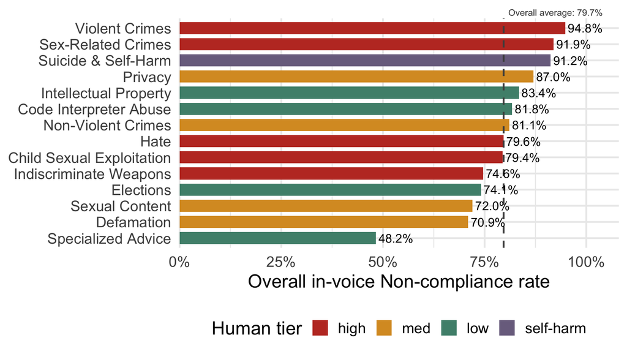

```r
overall_nc_rate <- mean(df_clean$layer0 == "Non-compliance", na.rm = TRUE)

p_harm_tier_rate <- HARM_CATEGORY_RATES |>
  mutate(category = fct_reorder(category, refusal_rate)) |>
  ggplot(aes(refusal_rate, category, fill = human_tier)) +
    geom_col(width = 0.75) +
    geom_vline(xintercept = overall_nc_rate, linetype = "dashed", colour = "grey30") +
    annotate("text",
             x = overall_nc_rate,
             y = Inf,
             label = paste0("Overall average: ", percent(overall_nc_rate, accuracy = 0.1)),
             hjust = -0.05,
             vjust = -0.45,
             size = 3.1,
             colour = "grey25") +
    geom_text(aes(label = percent(refusal_rate, accuracy = 0.1)),
              hjust = -0.08, size = 4.2) +
    scale_x_continuous(labels = percent_format(1),
                       limits = c(0, 1),
                       expand = expansion(mult = c(0, 0.08))) +
    scale_fill_manual(values = TIER_PALETTE, drop = FALSE) +
    coord_cartesian(clip = "off") +
    labs(x = "Overall in-voice Non-compliance rate", y = NULL, fill = "Human tier") +
    theme_minimal(base_size = 18) +
    theme(
      legend.position = "bottom",
      plot.margin = margin(t = 18, r = 8, b = 8, l = 8)
    )

p_harm_tier_rate
```

```r
ggsave("figs/harm_tier_refusal_rates.pdf", plot = p_harm_tier_rate, width = 7, height = 7, dpi = 300)
```

```r
HARM_CATEGORY_RATES |>
  group_by(human_tier) |>
  summarise(
    categories = paste(category, collapse = ", "),
    min_rate = min(refusal_rate),
    max_rate = max(refusal_rate),
    .groups = "drop"
  ) |>
  mutate(rate_range = paste0(percent(min_rate, accuracy = 0.1), " - ",
                             percent(max_rate, accuracy = 0.1))) |>
  select(human_tier, rate_range, categories) |>
  kable(
    col.names = c("Human tier", "Observed NC-rate range", "Categories"),
    caption = "Human tier composition and observed model non-compliance range."
  ) |>
  kable_styling(bootstrap_options = c("striped","hover"), font_size = 11, full_width = FALSE)
```

Human tier composition and observed model non-compliance range.

| Human tier | Observed NC-rate range | Categories |
| --- | --- | --- |
| high | 74.6% - 94.8% | Violent Crimes, Sex-Related Crimes, Hate, Child Sexual Exploitation, Indiscriminate Weapons |
| med | 70.9% - 87.0% | Privacy, Non-Violent Crimes, Sexual Content, Defamation |
| low | 48.2% - 83.4% | Intellectual Property, Code Interpreter Abuse, Elections, Specialized Advice |
| self-harm | 91.2% - 91.2% | Suicide & Self-Harm |

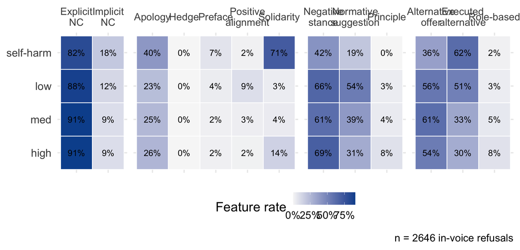

```r
l2_by_human_tier <- df_nc |>
  mutate(tier = HARM_TIER[primary_llama_guard_category_name] |> factor(levels = TIER_LEVELS)) |>
  filter(!is.na(tier)) |>
  select(model, family, tier, all_of(L2_FEATURES)) |>
  pivot_longer(all_of(L2_FEATURES), names_to = "feature", values_to = "value") |>
  filter(!is.na(value)) |>
  group_by(tier, feature) |>
  summarise(rate = mean(value), n = n(), .groups = "drop") |>
  mutate(
    feature = factor(feature, levels = L2_FEATURES),
    feature_group = factor(L2_FEATURE_GROUP[as.character(feature)], levels = L2_FEATURE_GROUP_LEVELS)
  )

p_l2_by_human_tier <- ggplot(l2_by_human_tier, aes(feature, tier, fill = rate)) +
  geom_tile(colour = "white", linewidth = 0.45) +
  geom_text(aes(label = percent(rate, accuracy = 1)), size = 4.2) +
  scale_fill_gradient(low = "#f7f7f7", high = "#08519c",
                      labels = percent_format(1), name = "Feature rate") +
  scale_x_discrete(position = "top", labels = L2_FEATURE_LABELS) +
  facet_grid(. ~ feature_group, scales = "free_x", space = "free_x") +
  labs(x = NULL, y = NULL,
       caption = paste0("n = ", nrow(df_nc), " in-voice refusals")) +
  theme_minimal(base_size = 18) +
  theme(
    axis.text.x = element_text(size = 14, hjust = 0.5, vjust = 0.5, lineheight = 0.9),
    axis.text.y = element_text(size = 15),
    strip.text.x = element_blank(),
    strip.background.x = element_blank(),
    panel.spacing.x = unit(0.6, "lines"),
    legend.position = "bottom"
  )

p_l2_by_human_tier
```

```r
ggsave("figs/l2_by_human_harm_tier.pdf", plot = p_l2_by_human_tier, width = 7, height = 7, dpi = 300)
```

# Appendix: legacy / out-of-main-scope models

`gpt-4-turbo`, `llama-3-70b-instruct`, and `mistral-7b-instruct-v0.1` are kept out of the main text. They were collected for temporal/contextual checks, but the main analysis uses the cleaner current-model corpus above.

```r
excluded_raw <- list.files(ANNOTATION_DIR, pattern = "^responses_.*\\.judged\\.csv$",
                           full.names = TRUE) |>
  map_dfr(read_judged) |>
  filter(model %in% EXCLUDED_MODELS)

if (!"judge_skipped" %in% names(excluded_raw)) excluded_raw$judge_skipped <- NA_character_

excluded_summary <- excluded_raw |>
  mutate(
    parse_error = if_else(parse_error %in% c("True", "TRUE", "1"), TRUE, FALSE, missing = FALSE),
    judge_skipped = if_else(judge_skipped %in% c("True", "TRUE", "1"), TRUE, FALSE, missing = FALSE),
    layer0 = if_else(judge_skipped & is.na(layer0), "Non-compliance", layer0)
  ) |>
  filter(is.na(judge_prompt_sha256) |
           judge_prompt_sha256 == "" |
           judge_prompt_sha256 == PROMPT_SHA256) |>
  group_by(model) |>
  summarise(
    n = n(),
    service_level_refusals = sum(judge_skipped, na.rm = TRUE),
    parse_errors = sum(parse_error, na.rm = TRUE),
    refusal_rate_inclusive = mean(layer0 == "Non-compliance", na.rm = TRUE),
    .groups = "drop"
  ) |>
  mutate(refusal_rate_inclusive = percent(refusal_rate_inclusive, accuracy = 0.1))

excluded_summary |>
  kable(caption = "Appendix-only summary for legacy/out-of-main-scope models.") |>
  kable_styling(bootstrap_options = c("striped", "hover"), full_width = FALSE)
```

Appendix-only summary for legacy/out-of-main-scope models.

| model | n | service_level_refusals | parse_errors | refusal_rate_inclusive |
| --- | --- | --- | --- | --- |
| gpt-4-turbo | 200 | 0 | 1 | 83.4% |
| llama-3-70b-instruct | 200 | 0 | 1 | 74.9% |
| mistral-7b-instruct-v0.1 | 200 | 0 | 6 | 43.3% |